# Lab 8: Differential expression with DESeq2

2026-10-19

# Learning objectives

By the end of this lab you should be able to:

1. Read, reshape, and plot tabular data in R using the tidyverse.
2. Build a `DESeqDataSet`, run differential expression, and interpret the results table.
3. Use exploratory plots (PCA, sample distance heatmaps) to assess the quality and structure of your samples.
4. Reason about what a “no significant genes” result can and cannot tell you.

# Background

We have bulk RNA-seq from **8 mice**: 4 wild-type (WT) and 4 knockout (KO). Reads were aligned and counted per gene with `verse`. Our question is simple:

> **Which genes are differentially expressed between KO and WT?**

Each sample is named `<genotype>_<mouse ID>`, e.g. `KO_840`.

This was a real experiment, and the information given here is what was originally available.

# Part 0: Getting started with R

You don’t need to know any R before this lab. This part covers everything you need for Part 1. In later parts you’ll write some code yourself, usually by adapting an example from earlier in the lab. The goal is to understand what the code does. If you’re already experienced with R, you can skip this part.

## 0.1 How this document works

This file is an **R Markdown** document (`.Rmd`). It mixes ordinary text (like this paragraph) with **code chunks**: grey boxes that start with `` ```{r} ``.

- **Run one chunk:** click the green ▶ arrow at the top right of the chunk, or put your cursor inside it and press **Ctrl+Shift+Enter** (Mac: **Cmd+Shift+Enter**).
- **Run one line:** put your cursor on the line and press **Ctrl+Enter** (Mac: **Cmd+Enter**).
- The output appears directly under the chunk.

> **Run chunks in order.** Many chunks use results from earlier ones. If you see `Error: object 'something' not found`, you probably skipped a chunk above.

Try it: run the chunk below.

```r
2 + 3
```

```
## [1] 5
```

## 0.2 Comments

A `#` is the comment symbol in R.

```r
# This line does nothing
10 * 4   # R runs the code before the #, and ignores the rest
```

```
## [1] 40
```

## 0.3 Saving results in objects

The arrow `<-` stores a value under a name so you can use it later, exactly the same concept as assigning values to variables in other languages.

```r
x <- 5
y <- x * 2
y
```

```
## [1] 10
```

Typing an object’s name on its own line prints it.

## 0.4 Functions

A **function** does something to its inputs, called **arguments**, which go inside parentheses and are separated by commas. Some arguments have names.

```r
round(3.14159)               # one argument
```

```
## [1] 3
```

```r
round(3.14159, digits = 2)   # a second, named argument
```

```
## [1] 3.14
```

To read the help page for any function, type `?round` in the **Console** (bottom left).

## 0.5 Vectors: lists of values

`c()` (“combine”) makes a **vector**, which is a list of values of the same type.

```r
read_depths <- c(40, 91, 79, 75)      # numbers
mean(read_depths)
```

```
## [1] 71.25
```

```r
genotypes <- c("WT", "KO", "WT", "KO") # text ("character") values go in quotes
genotypes
```

```
## [1] "WT" "KO" "WT" "KO"
```

## 0.6 Packages

A **package** is a bundle of extra functions that someone else wrote. We use:

- **tidyverse**: reading, reshaping, and plotting tables
- **DESeq2**: differential expression analysis
- **pheatmap** and **RColorBrewer**: heatmaps and color palettes

These packages below should already be installed by default on the SCC.

```r
# Run every session
library(tidyverse)
library(DESeq2)
library(pheatmap)
library(RColorBrewer)
```

## 0.7 Working with tables in the tidyverse

Most of the table work in this lab uses a handful of tidyverse functions. To practice, here is a small made-up table. `tibble()` builds a table one column at a time.

The tidyverse set of functions were designed to be intuitive, expressive, and you should almost be able to read tidyverse code as plain text. You’ll notice that most tidyverse functions are named as verbs that describe what it does, and you chain them together in the steps that you are performing on the data.

```r
genes <- tibble(
  gene   = c("Actb", "Gapdh", "Sox2", "Pax6", "Alb", "Ttr"),
  tissue = c("brain", "brain", "brain", "brain", "liver", "liver"),
  count  = c(1500, 2200, 340, 15, 5000, 4100),
  length = c(1.9, 1.4, 2.5, 3.2, 2.1, 0.8)   # kilobases
)
genes
```

```
## # A tibble: 6 × 4
##   gene  tissue count length
##   <chr> <chr>  <dbl>  <dbl>
## 1 Actb  brain   1500    1.9
## 2 Gapdh brain   2200    1.4
## 3 Sox2  brain    340    2.5
## 4 Pax6  brain     15    3.2
## 5 Alb   liver   5000    2.1
## 6 Ttr   liver   4100    0.8
```

**The pipe, `%>%`**, passes the table on its left into the function on its right. Read it as “and then”. It works much like the bash `|` pipe. Every function below takes a table and returns a new table, so they can be chained together with pipes.

`select()` keeps **columns**:

```r
genes %>% select(gene, count)      # keep only these columns
```

```
## # A tibble: 6 × 2
##   gene  count
##   <chr> <dbl>
## 1 Actb   1500
## 2 Gapdh  2200
## 3 Sox2    340
## 4 Pax6     15
## 5 Alb    5000
## 6 Ttr    4100
```

```r
genes %>% select(-length)          # keep everything except length
```

```
## # A tibble: 6 × 3
##   gene  tissue count
##   <chr> <chr>  <dbl>
## 1 Actb  brain   1500
## 2 Gapdh brain   2200
## 3 Sox2  brain    340
## 4 Pax6  brain     15
## 5 Alb   liver   5000
## 6 Ttr   liver   4100
```

`filter()` keeps **rows** that meet a condition:

```r
genes %>% filter(count > 1000)                       # one condition
```

```
## # A tibble: 4 × 4
##   gene  tissue count length
##   <chr> <chr>  <dbl>  <dbl>
## 1 Actb  brain   1500    1.9
## 2 Gapdh brain   2200    1.4
## 3 Alb   liver   5000    2.1
## 4 Ttr   liver   4100    0.8
```

```r
genes %>% filter(tissue == "brain", count > 100)     # both conditions must be true
```

```
## # A tibble: 3 × 4
##   gene  tissue count length
##   <chr> <chr>  <dbl>  <dbl>
## 1 Actb  brain   1500    1.9
## 2 Gapdh brain   2200    1.4
## 3 Sox2  brain    340    2.5
```

```r
genes %>% filter(gene %in% c("Sox2", "Alb"))         # gene is one of these
```

```
## # A tibble: 2 × 4
##   gene  tissue count length
##   <chr> <chr>  <dbl>  <dbl>
## 1 Sox2  brain    340    2.5
## 2 Alb   liver   5000    2.1
```

`mutate()` adds a new column, or changes an existing one:

```r
genes %>% mutate(count_per_kb = count / length)
```

```
## # A tibble: 6 × 5
##   gene  tissue count length count_per_kb
##   <chr> <chr>  <dbl>  <dbl>        <dbl>
## 1 Actb  brain   1500    1.9       789.
## 2 Gapdh brain   2200    1.4      1571.
## 3 Sox2  brain    340    2.5       136
## 4 Pax6  brain     15    3.2         4.69
## 5 Alb   liver   5000    2.1      2381.
## 6 Ttr   liver   4100    0.8      5125
```

`arrange()` sorts rows. Wrap the column in `desc()` for largest first:

```r
genes %>% arrange(desc(count))
```

```
## # A tibble: 6 × 4
##   gene  tissue count length
##   <chr> <chr>  <dbl>  <dbl>
## 1 Alb   liver   5000    2.1
## 2 Ttr   liver   4100    0.8
## 3 Gapdh brain   2200    1.4
## 4 Actb  brain   1500    1.9
## 5 Sox2  brain    340    2.5
## 6 Pax6  brain     15    3.2
```

Chain several steps together, and save the result with `<-`:

```r
brain_top <- genes %>%
  filter(tissue == "brain") %>%                  # brain genes only
  mutate(count_per_kb = count / length) %>%      # add a column
  arrange(desc(count_per_kb)) %>%                # sort, largest first
  select(gene, count_per_kb)                     # keep two columns
brain_top
```

```
## # A tibble: 4 × 2
##   gene  count_per_kb
##   <chr>        <dbl>
## 1 Gapdh      1571.
## 2 Actb        789.
## 3 Sox2        136
## 4 Pax6          4.69
```

None of these functions change `genes` itself. Print `genes` again and you’ll see it is unchanged. To keep a result, assign it to a name, as with `brain_top` above.

# Part 1: Loading and tidying the counts

Most of the code in this lab comes directly from the [DESeq2 tutorial](https://bioconductor.org/packages/devel/bioc/vignettes/DESeq2/inst/doc/DESeq2.html).

All the code in this part is provided. Run each chunk, read the comments, and answer the questions.

## 1.1 Read the counts into R

The counts are in a **tab-separated** text file, which is a spreadsheet saved as plain text. `read_tsv()` reads it into a table. In R, a table is called a **data frame**. The tidyverse version of a data frame is called a **tibble**, and the `read_tsv` function reads in this TSV as a tibble.

```r
# The file must be in the same folder as this .Rmd
raw <- read_tsv("all_verse_counts.tsv")
raw
```

```
## # A tibble: 48,440 × 10
##     ...1 gene_id             WT_842_count KO_857_count WT_892_count KO_891_count
##    <dbl> <chr>                      <dbl>        <dbl>        <dbl>        <dbl>
##  1     0 ENSMUSG00000102693…            0            0            0            0
##  2     1 ENSMUSG00000064842…            0            0            0            0
##  3     2 ENSMUSG00000051951…          237         1397         1189          442
##  4     3 ENSMUSG00000102851…            0            0            0            0
##  5     4 ENSMUSG00000103377…            0            1            0            0
##  6     5 ENSMUSG00000104017…            0            0            0            0
##  7     6 ENSMUSG00000103025…            1            1            0            0
##  8     7 ENSMUSG00000089699…            0            0            0            0
##  9     8 ENSMUSG00000103201…            0            0            0            0
## 10     9 ENSMUSG00000103147…            3            0            0            0
## # ℹ 48,430 more rows
## # ℹ 4 more variables: WT_841_count <dbl>, KO_843_count <dbl>,
## #   WT_858_count <dbl>, KO_840_count <dbl>
```

Now look at what we loaded:

```r
head(raw)        # the first 6 rows
```

```
## # A tibble: 6 × 10
##    ...1 gene_id WT_842_count KO_857_count WT_892_count KO_891_count WT_841_count
##   <dbl> <chr>          <dbl>        <dbl>        <dbl>        <dbl>        <dbl>
## 1     0 ENSMUS…            0            0            0            0            0
## 2     1 ENSMUS…            0            0            0            0            0
## 3     2 ENSMUS…          237         1397         1189          442          671
## 4     3 ENSMUS…            0            0            0            0            0
## 5     4 ENSMUS…            0            1            0            0            0
## 6     5 ENSMUS…            0            0            0            0            1
## # ℹ 3 more variables: KO_843_count <dbl>, WT_858_count <dbl>,
## #   KO_840_count <dbl>
```

```r
dim(raw)         # number of rows, number of columns
```

```
## [1] 48440    10
```

```r
colnames(raw)    # the column names
```

```
##  [1] "...1"         "gene_id"      "WT_842_count" "KO_857_count" "WT_892_count"
##  [6] "KO_891_count" "WT_841_count" "KO_843_count" "WT_858_count" "KO_840_count"
```

Each **row** is a gene and each **column** is a sample. Each number is the count of reads that mapped to that gene in that sample. You can also click `raw` in the Environment pane to open it like a spreadsheet.

To pull out a single column, use `$`:

```r
head(raw$gene_id)
```

```
## [1] "ENSMUSG00000102693.1" "ENSMUSG00000064842.1" "ENSMUSG00000051951.5"
## [4] "ENSMUSG00000102851.1" "ENSMUSG00000103377.1" "ENSMUSG00000104017.1"
```

**Q1.1** How many genes are in the table?

**Q1.2** How many genes **should** be in the table, and how would you know this?

## 1.2 The pipe: `%>%`

You met the pipe, `%>%`, in section 0.7. It works with any function, not only the tidyverse ones, and here it is on the real data.

```r
# These two lines do the same thing:
head(colnames(raw))
```

```
## [1] "...1"         "gene_id"      "WT_842_count" "KO_857_count" "WT_892_count"
## [6] "KO_891_count"
```

```r
raw %>% colnames() %>% head()   # "take raw, then get its column names, then show the first few"
```

```
## [1] "...1"         "gene_id"      "WT_842_count" "KO_857_count" "WT_892_count"
## [6] "KO_891_count"
```

The pipe is easier to read when there are many steps, so you’ll see it a lot.

## 1.3 Clean up the table

There are two problems to fix:

1. The first column is a leftover row number from the program that wrote the file. It isn’t data.
2. Every sample name ends in `_count`, which is not needed for further analysis.

You should end up with a dataframe that has a column for the gene_id and a column for all 8 samples. The number of rows represents the number of genes in the experiment.

```r
counts <- raw %>%
  select(-1) %>%                                   # drop column number 1
  rename_with(~ str_remove(.x, "_count"))          # remove "_count" from every column name

head(counts)
```

```
## # A tibble: 6 × 9
##   gene_id              WT_842 KO_857 WT_892 KO_891 WT_841 KO_843 WT_858 KO_840
##   <chr>                 <dbl>  <dbl>  <dbl>  <dbl>  <dbl>  <dbl>  <dbl>  <dbl>
## 1 ENSMUSG00000102693.1      0      0      0      0      0      0      0      0
## 2 ENSMUSG00000064842.1      0      0      0      0      0      0      0      0
## 3 ENSMUSG00000051951.5    237   1397   1189    442    671    415    189    342
## 4 ENSMUSG00000102851.1      0      0      0      0      0      0      0      0
## 5 ENSMUSG00000103377.1      0      1      0      0      0      0      0      2
## 6 ENSMUSG00000104017.1      0      0      0      0      1      0      0      0
```

- `select()` chooses columns. A minus sign means “everything **except**”.
- `rename_with()` applies the same renaming rule to every column name. Here the rule is `str_remove(.x, "_count")`, where `.x` stands for “each name”.

**Q1.3** Print `colnames(counts)`. Do the sample names now look like `WT_842`?

## 1.4 Wide vs. long tables

`counts` is a **wide** table, with one column per sample:

| gene_id | WT_842 | KO_857 | … |
| --- | --- | --- | --- |
| geneA | 237 | 1397 | … |

Most plotting functions want a **long** table instead, with one row per measurement:

| gene_id | sample | count |
| --- | --- | --- |
| geneA | WT_842 | 237 |
| geneA | KO_857 | 1397 |

`pivot_longer()` converts wide to long. Then `separate()` splits `"WT_842"` into a genotype column and a mouse column.

```r
counts_long <- counts %>%
  pivot_longer(-gene_id,                         # every column except gene_id...
               names_to  = "sample",             # ...the old column names go here
               values_to = "count") %>%          # ...the numbers go here
  separate(sample,
           into = c("condition", "mouse"),       # split on the "_"
           remove = FALSE)                       # keep the original sample column too

head(counts_long)
```

```
## # A tibble: 6 × 5
##   gene_id              sample condition mouse count
##   <chr>                <chr>  <chr>     <chr> <dbl>
## 1 ENSMUSG00000102693.1 WT_842 WT        842       0
## 2 ENSMUSG00000102693.1 KO_857 KO        857       0
## 3 ENSMUSG00000102693.1 WT_892 WT        892       0
## 4 ENSMUSG00000102693.1 KO_891 KO        891       0
## 5 ENSMUSG00000102693.1 WT_841 WT        841       0
## 6 ENSMUSG00000102693.1 KO_843 KO        843       0
```

**Q1.4** `counts` has 8 sample columns. How many rows should `counts_long` have? Check with `nrow(counts_long)`.

## 1.5 Your first plot

R draws plots with **ggplot**. A ggplot is built from layers joined with `+`:

1. `ggplot(data, aes(...))` says which table to use and which columns go on which axis. `aes()` stands for “aesthetics”.
2. A `geom_...()` says what to draw: bars, points, lines, and so on.
3. Optional extra layers change labels, colors, and themes.

Here are the raw counts for one gene across all 8 samples:

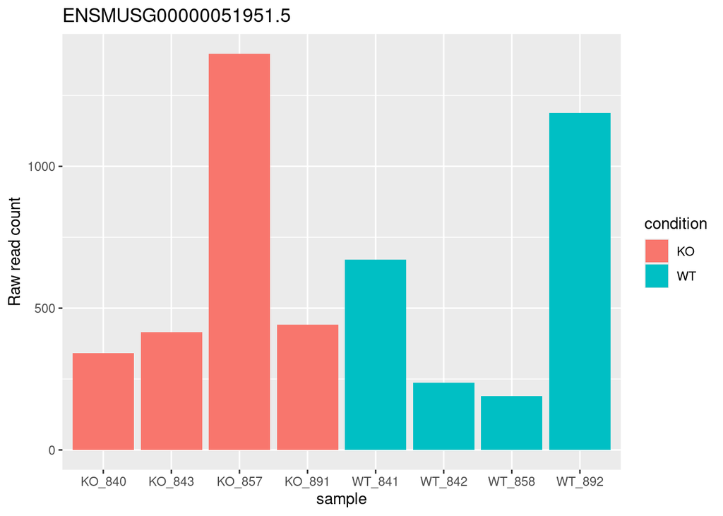

```r
counts_long %>%
  filter(gene_id == "ENSMUSG00000051951.5") %>%          # keep only rows for one gene
  ggplot(aes(x = sample, y = count, fill = condition)) + # map columns to the plot
  geom_col() +                                           # draw bars
  labs(title = "ENSMUSG00000051951.5", y = "Raw read count")
```

Note that `==` **tests** whether two things are equal, while `=` and `<-` **assign** values.

**Try it:** copy the chunk above and change the gene ID (in both places) to `"ENSMUSG00000025902.13"`. Then try changing `geom_col()` to `geom_point(size = 3)`.

## 1.6 The sample table

DESeq2 needs a second table that describes each sample. It’s called **colData** because it describes the *columns* of the count matrix. We build it from the sample names.

```r
coldata <- tibble(sample = colnames(counts)[-1]) %>%   # all column names except gene_id
  separate(sample, into = c("condition", "mouse"), remove = FALSE) %>% # separate splits the sample name on the _
  mutate(condition = factor(condition, levels = c("WT", "KO"))) # we turn condition into a factor
coldata
```

```
## # A tibble: 8 × 3
##   sample condition mouse
##   <chr>  <fct>     <chr>
## 1 WT_842 WT        842
## 2 KO_857 KO        857
## 3 WT_892 WT        892
## 4 KO_891 KO        891
## 5 WT_841 WT        841
## 6 KO_843 KO        843
## 7 WT_858 WT        858
## 8 KO_840 KO        840
```

- `[-1]` means “everything except the first item”.
- `mutate()` creates or changes a column.
- `factor()` tells R that `condition` is a category with a fixed set of levels. The **first level is the reference**, which is the group everything else is compared against.

**Q1.5** Why do we want `WT` as the reference level? If KO were the reference, what would happen to the sign (+/−) of the fold changes?

# Part 2: Quality control and exploration

## 2.1 Build the DESeq2 object

```r
# Need to convert the counts to a matrix
mat <- counts %>% column_to_rownames("gene_id") %>% as.matrix()

# Constructs the DESeq2 object that bundles the counts, coldata, and design formula together
dds <- DESeqDataSetFromMatrix(countData = mat,
                              colData   = coldata,
                              design    = ~ condition)
dds
```

```
## class: DESeqDataSet
## dim: 48440 8
## metadata(1): version
## assays(1): counts
## rownames(48440): ENSMUSG00000102693.1 ENSMUSG00000064842.1 ...
##   ENSMUSG00000064371.1 ENSMUSG00000064372.1
## rowData names(0):
## colnames(8): WT_842 KO_857 ... WT_858 KO_840
## colData names(3): sample condition mouse
```

Our design is `~condition` which instructs DESeq2 to model the gene counts as a function of a single experimental factor. In our case, this condition represents the difference between our wild-type and KO mice of interest. DESeq2 will fit a generalized linear model (GLM) to each gene, assuming its counts can be modeled by a negative binomial distribution.

## 2.2 Filter low-count genes

Genes with almost no reads carry no information and only add to the multiple-testing burden. `counts(dds)` returns the count matrix stored inside `dds`. This filtering strategy comes directly from the DESeq2 vignette, but in the future, you likely want to come up with more elegant filtering strategies that also take into consideration the number of replicates in each condition.

```r
keep <- rowSums(counts(dds) >= 10) >= 4
dds <- dds[keep, ]
nrow(dds)
```

```
## [1] 15788
```

**Q2.1** How many genes did you remove?

## 2.3 PCA and sample distances

Many machine learning methods including PCA, and clustering assume roughly constant variance across features. RNA-seq count data explicitly breaks this assumption as the variance scales with the mean. The DESeq2 variance stabilizing transformation (vst) is one possible method to stabilize the variance.

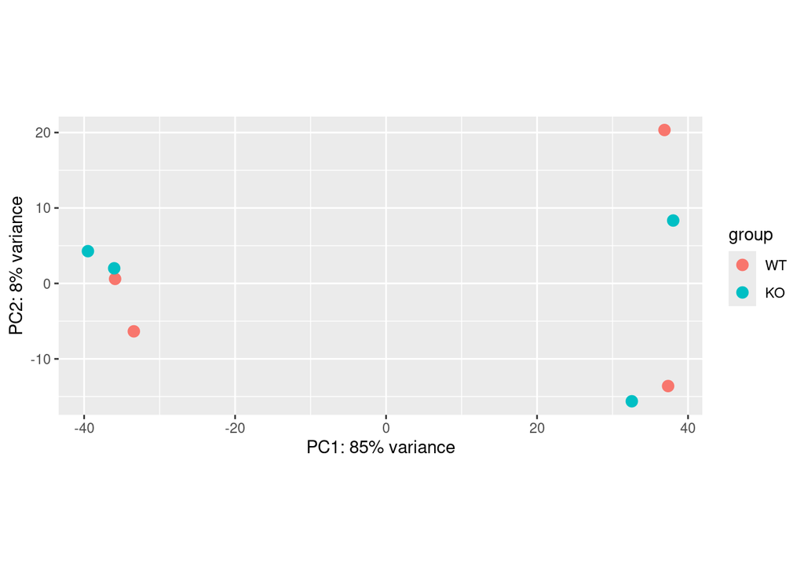

```r
# This is directly from the DESeq2 vignette
# Makes a PCA biplot colored by metadata from our samples
vsd <- vst(dds, blind = TRUE)
plotPCA(vsd, intgroup = "condition")
```

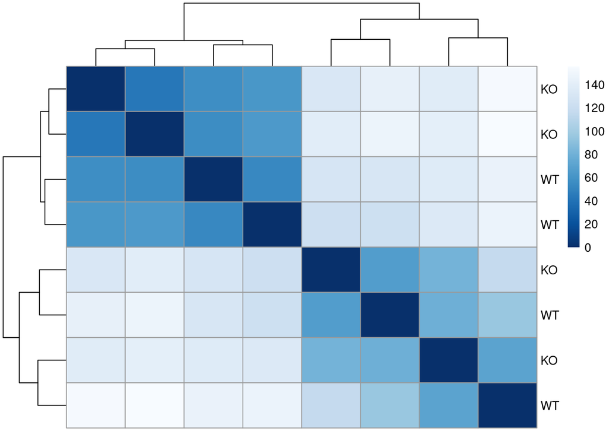

```r
# Also directly from the DEseq2 vignette
sampleDists <- dist(t(assay(vsd)))
sampleDistMatrix <- as.matrix(sampleDists)
rownames(sampleDistMatrix) <- vsd$condition
colnames(sampleDistMatrix) <- NULL
colors <- colorRampPalette(rev(brewer.pal(9, "Blues")))(255)
pheatmap(sampleDistMatrix,
         clustering_distance_rows = sampleDists,
         clustering_distance_cols = sampleDists,
         col = colors)
```

**Q2.2** What does PC1 separate? Does it match genotype?

**Q2.3** In the heatmap, which samples are most similar to each other? Write down your hypothesis for what is driving this structure.

# Part 3: The initial analysis (`~ condition`)

```r
# This runs the DESeq2 method - normalization, testing of each gene with a GLM
dds <- DESeq(dds)

# This makes the results available in a data frame
res_basic <- results(dds, name = "condition_KO_vs_WT")
```

```r
# TODO: convert to tibble, arrange by padj
res_tbl <- res_basic %>% as_tibble(rownames = "gene_id") %>% arrange(padj)
res_tbl
```

```
## # A tibble: 15,788 × 7
##    gene_id               baseMean log2FoldChange lfcSE   stat   pvalue     padj
##    <chr>                    <dbl>          <dbl> <dbl>  <dbl>    <dbl>    <dbl>
##  1 ENSMUSG00000082536.1     1518.         -3.72  0.356 -10.5  1.43e-25 2.25e-21
##  2 ENSMUSG00000104802.1      249.         -3.58  0.405  -8.85 9.05e-19 7.13e-15
##  3 ENSMUSG00000025420.13     316.         -0.865 0.126  -6.85 7.51e-12 3.94e- 8
##  4 ENSMUSG00000055027.17     329.         -2.20  0.332  -6.61 3.82e-11 1.20e- 7
##  5 ENSMUSG00000022803.12     737.         -1.04  0.156  -6.64 3.23e-11 1.20e- 7
##  6 ENSMUSG00000027875.12    2069.         -2.91  0.465  -6.26 3.73e-10 9.79e- 7
##  7 ENSMUSG00000004035.12     367.         -1.55  0.248  -6.23 4.75e-10 1.07e- 6
##  8 ENSMUSG00000032334.9     4013.          1.06  0.175   6.05 1.43e- 9 2.52e- 6
##  9 ENSMUSG00000017639.13     578.         -1.82  0.300  -6.05 1.44e- 9 2.52e- 6
## 10 ENSMUSG00000026452.15     238.          2.70  0.449   6.01 1.86e- 9 2.92e- 6
## # ℹ 15,778 more rows
```

**Q3.1** How many genes are significant at `padj < 0.1`? Use the `filter()` function.

```r
res_tbl %>% filter(padj < 0.1)
```

```
## # A tibble: 146 × 7
##    gene_id               baseMean log2FoldChange lfcSE   stat   pvalue     padj
##    <chr>                    <dbl>          <dbl> <dbl>  <dbl>    <dbl>    <dbl>
##  1 ENSMUSG00000082536.1     1518.         -3.72  0.356 -10.5  1.43e-25 2.25e-21
##  2 ENSMUSG00000104802.1      249.         -3.58  0.405  -8.85 9.05e-19 7.13e-15
##  3 ENSMUSG00000025420.13     316.         -0.865 0.126  -6.85 7.51e-12 3.94e- 8
##  4 ENSMUSG00000055027.17     329.         -2.20  0.332  -6.61 3.82e-11 1.20e- 7
##  5 ENSMUSG00000022803.12     737.         -1.04  0.156  -6.64 3.23e-11 1.20e- 7
##  6 ENSMUSG00000027875.12    2069.         -2.91  0.465  -6.26 3.73e-10 9.79e- 7
##  7 ENSMUSG00000004035.12     367.         -1.55  0.248  -6.23 4.75e-10 1.07e- 6
##  8 ENSMUSG00000032334.9     4013.          1.06  0.175   6.05 1.43e- 9 2.52e- 6
##  9 ENSMUSG00000017639.13     578.         -1.82  0.300  -6.05 1.44e- 9 2.52e- 6
## 10 ENSMUSG00000026452.15     238.          2.70  0.449   6.01 1.86e- 9 2.92e- 6
## # ℹ 136 more rows
```

# Part 4: What might have gone wrong?

You’ll notice that we observe only 146 genes that are differentially expressed. When this experiment was performed, the scientists involved were surprised that the effect was so small and expected more genes to be changed.

That suspicion alone did not allow for any firm conclusions since there are any number of technical and biological reasons for this, including:

1. The knockout of the gene truly has a small or no biological effect.
2. The samples were of poor quality, or the pipeline didn’t process them correctly.

As it happens, the researchers in question were fairly confident that the rest of the experiment was successful and of high quality, and that there *should* be, based on their other knowledge and experiments, a more robust effect on gene expression (i.e. more genes that are changed between conditions)

**Q4.1** Write down your best hypothesis, and the evidence from this lab that supports it. We’ll discuss as a class before moving on to the re-analysis.